# Exam 01: Takehome Portion (Solutions)

## Instructions

Deadline: Monday, 12 February 2024 at the start of class

Good luck!

## Weather in NYC

The data set for this exam consists of a single year of observed weather data from New York City. Read in the data set with this command:

```r
source("../funs/funs.R")
weather <- read_csv("../data/weather-nyc.csv")
```

Here is a data dictionary for the features:

- **date**: the date of the weather record, formatted YYYY-MM-DD
- **actual_mean_temp**: the measured average temperature for that day (Celsius)
- **actual_min_temp**: the measured minimum temperature for that day (Celsius)
- **actual_max_temp**: the measured maximum temperature for that day (Celsius)
- **average_min_temp**: the average minimum temperature on that day since 1880 (Celsius)
- **average_max_temp**: the average maximum temperature on that day since 1880 (Celsius)
- **record_min_temp**: the lowest ever temperature on that day since 1880 (Celsius)
- **record_max_temp**: the highest ever temperature on that day since 1880 (Celsius)
- **record_min_temp_year**: the year that the lowest ever temperature occurred
- **record_max_temp_year**: the year that the highest ever temperature occurred
- **actual_precipitation**: the measured amount of rain or snow for that day (cm)
- **average_precipitation**: the average amount of rain or snow on that day since 1880 (cm)
- **record_precipitation**: the highest amount of rain or snow on that day since 1880 (cm)
- **month**: month of the year as a string
- **description**: text description of the weather, either “dry”, “rain”, or “snow”

If you have questions about what these features mean, please let me know.

## 1. A straightforward line plot

In the first plot, create a line plot (i.e., use `geom_line`) with date on the x-axis and the ACTUAL maximum temperature on the y-axis.

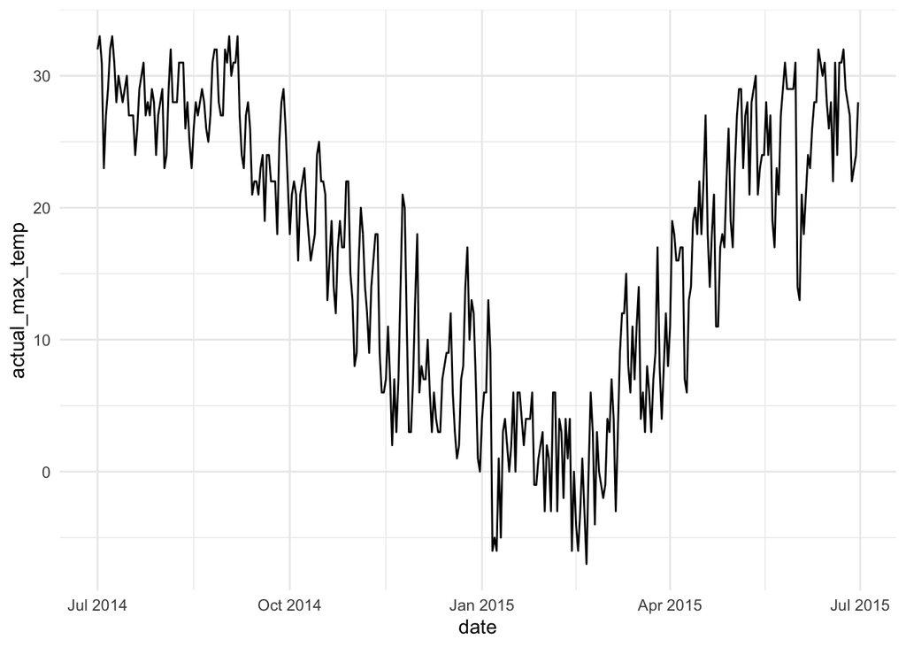

```r
weather |>
  ggplot(aes(date, actual_max_temp)) +
    geom_line()
```

## 2. Line plot with fixed color

Now, create a line plot (i.e., use `geom_line`) with date on the x-axis and the AVERAGE maximum temperature on the y-axis. Make the line the color “red”.

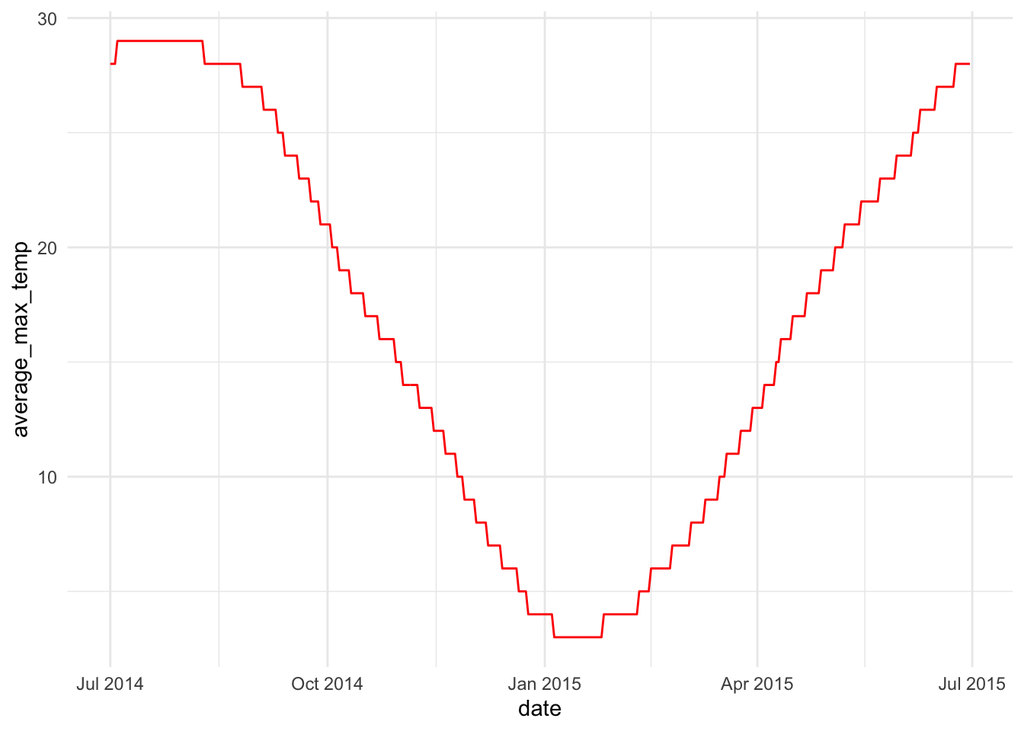

```r
weather |>
  ggplot(aes(date, average_max_temp)) +
    geom_line(color = "red")
```

## 3. Two Lines

Create a plot that layers your solutions to the first two questions into a single plot. In other words, it will have date on the x-axis and two lines: one in black showing the actual maximum temperature and one in red showing the average maximum temperature.

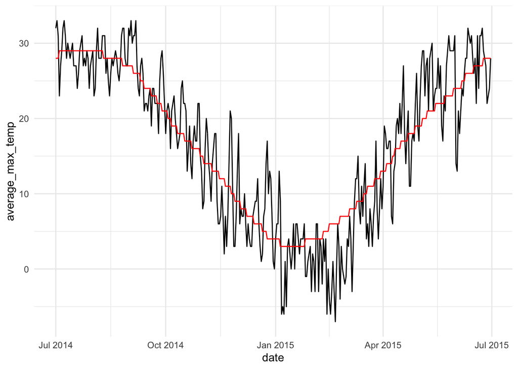

```r
weather |>
  ggplot(aes(date, average_max_temp)) +
    geom_line(aes(y = actual_max_temp)) +
    geom_line(color = "red")
```

## 4. Two lines on one plot with colors

In this plot, layer two line geometries (in other words, there will two lines) that show the actual minimum temperature and the actual maximum temperature, with date on the x-axis. Color the minimum temperature with the color “#5be5e5” (it’s a pretty shade of blue) and the maximum temperature with the color “#ff6666” (a pretty shade of red).

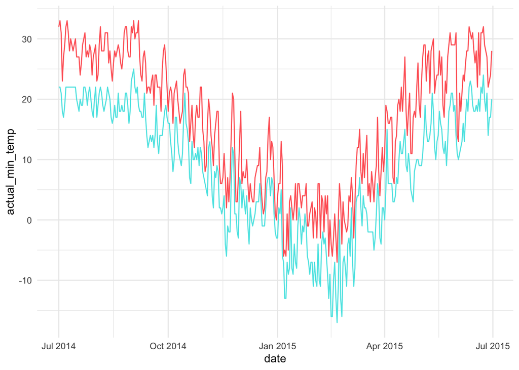

```r
weather |>
  ggplot(aes(date, actual_min_temp)) +
    geom_line(color = "#5be5e5") +
    geom_line(aes(y = actual_max_temp), color = "#ff6666")
```

## 5. Variable Color

Now, construct a scatter plot with average maximum temperature on the x-axis and record maximum temperature on the y-axis. Color the points according to the month of the year using the color-blind friendly viridis scale.

Note that the ordering of the months will be alphabetical; this is not ideal in general, but fine for now!

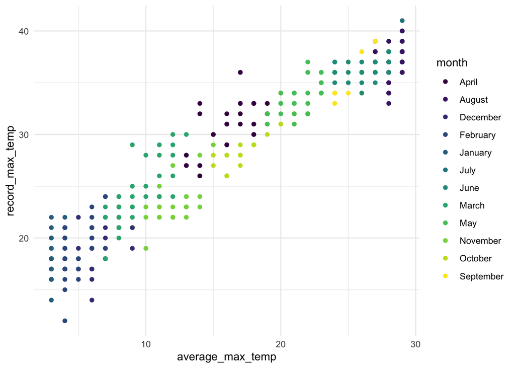

```r
weather |>
  ggplot(aes(average_max_temp, record_max_temp)) +
    geom_point(aes(color = month)) +
    scale_color_viridis_d()
```

Create a scatter plot with with average maximum temperature on the x-axis and record maximum temperature on the y-axis. Color all the points with the color “grey”. Add a layer on top of this consisting of a scatter plot with only those days for which it was snowing colored in “blue”.

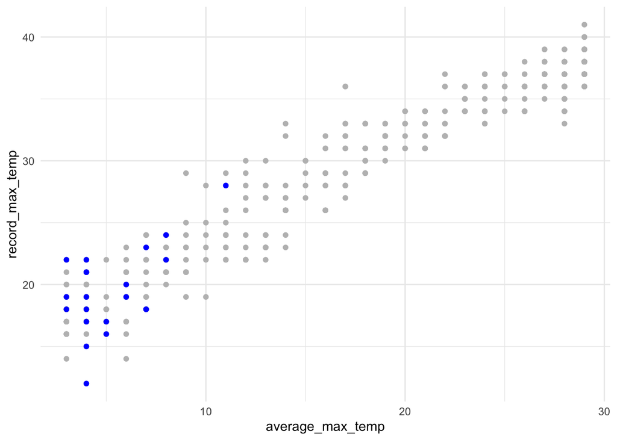

```r
snowy_days <- weather |>
  filter(description == "snow")

weather |>
  ggplot(aes(average_max_temp, record_max_temp)) +
    geom_point(color = "grey") +
    geom_point(color = "blue", data = snowy_days)
```

## 7. Summer: Layer Call Out

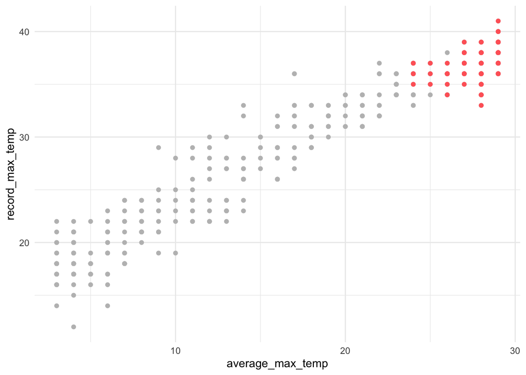

```r
summer <- weather |>
  filter(month %in% c("June", "July", "August"))

weather |>
  ggplot(aes(average_max_temp, record_max_temp)) +
    geom_point(color = "grey") +
    geom_point(color = "#ff6666", data = summer)
```

## 8. Segments

In this plot you are going to make use of the geometry layer `geom_segment`. I showed this in the slides, but you may not have used it yourself. It creates a set of short line segments and requires four aesthetics: the x and y aesthetics control where the segment begins and the xend and yend aesthetics describe what features determine where the segment ends.

The plot should have date again on the x-axis. Using a geom_segment layer, create segments that start with a y-value of actual_max_temp and proceed down to the y-value of actual_min_temp. That is, each day will have a vertical line going from the high temperature to the low temperature.

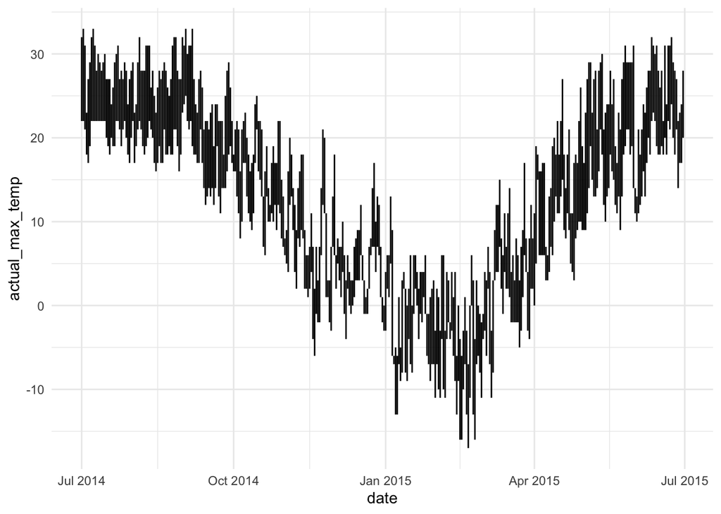

```r
weather |>
  ggplot(aes(date, actual_max_temp)) +
    geom_segment(aes(xend = date, yend = actual_min_temp))
```

## 9. Coldest Days

Create a line plot with date on the x-axis and actual maximum temperature on the y-axis. Add a point layer showing the coldest 15 days in the data. Color these points in the color “#5be5e5”.

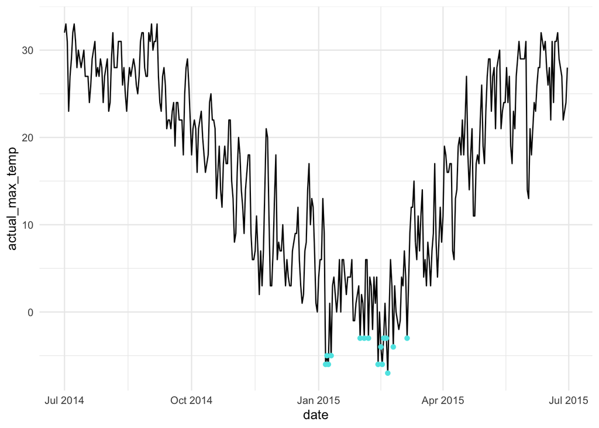

```r
coldest_days <- weather |>
  arrange(actual_max_temp) |>
  slice(1:15)

weather |>
  ggplot(aes(date, actual_max_temp)) +
    geom_line() +
    geom_point(data = coldest_days, color = "#5be5e5")
```